# Indicator Heterogeneity I: Should we include an intercept?

Addison

### High level summary

- A longer time window (in Aaron’s approach) yields slopes that capture some information (no longer centered on zero) but the spread is still rather large, with the +/- 1 MAD interval covering zero.
- Omitting the slope term still yields good correlation results. But too good to be true?

Next steps: try no slope, but with longer time window (-42:-8).

### Background and setup

This notebook was motivated by the fact that in my original analysis, we found extremely high correlation between sensorized DV and cases when we sensorized using 7 days in past until 1 day in past, **but** the slopes were found to be centered on zero. This leads us to believe that all the information was being captured in the intercept, and we had essentially produced a smooth version of case rate.

Here, we compare two alternatives. One is a longer time window (42 days in past to 8 days in past), which corresponds to [Aaron’s sensorization approach](https://delphi.cmu.edu/blog/2020/11/05/a-syndromic-covid-19-indicator-based-on-insurance-claims-of-outpatient-visits/), retaining the slope and intercept terms; and the other is a shorter time window (7 days in past to 1 day in past; 21 days in past to 1 day in past) but where we omit the intercept term.

For the latter model, we also fit -10:-1; -14:-1. These achieve correlations in between -7:-1 and -21:-1.

```r
longer_time_cors = readRDS('results/08_sensorize_cors_doctor-visits_smoothed_adj_cli.RDS')
no_slope_cors = readRDS('results/09_sensorize_cors_doctor-visits_smoothed_adj_cli.RDS')
# Plot correlation

lt_df = longer_time_cors[[4]]
lt_df$Indicator = 'Slope+Intercept; -42:-8'

ns_df = no_slope_cors[[1]]
ns_df$Indicator = 'Slope only; -7:-1'

ns_wider_df = no_slope_cors[[4]]
ns_wider_df$Indicator = 'Slope only; -21:-1'

lt_slopes = readRDS('results/08_sensorize_vals_doctor-visits_smoothed_adj_cli.RDS')[[4]]
ns_slopes_list = readRDS('results/09_sensorize_vals_doctor-visits_smoothed_adj_cli.RDS')
ns_slopes = ns_slopes_list[[1]]
ns_wider_slopes = ns_slopes_list[[4]]
```

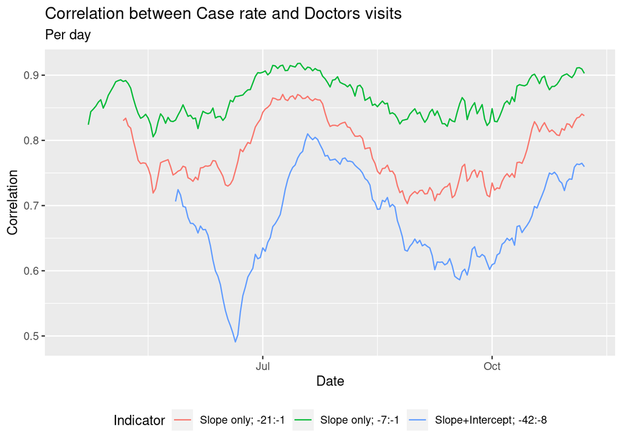

```r
plt = ggplot(bind_rows(lt_df, ns_df, ns_wider_df), aes(x = time_value, y = value)) +
  geom_line(aes(color = Indicator)) +
  labs(title = sprintf("Correlation between Case rate and Doctors visits"),
       subtitle = "Per day",
       x = "Date", y = "Correlation") +
  theme(legend.position = "bottom")
print(plt)
```

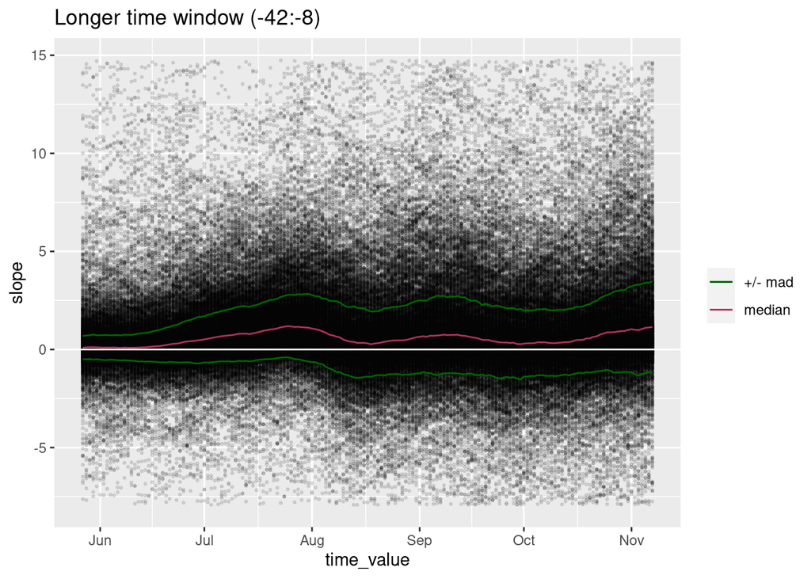

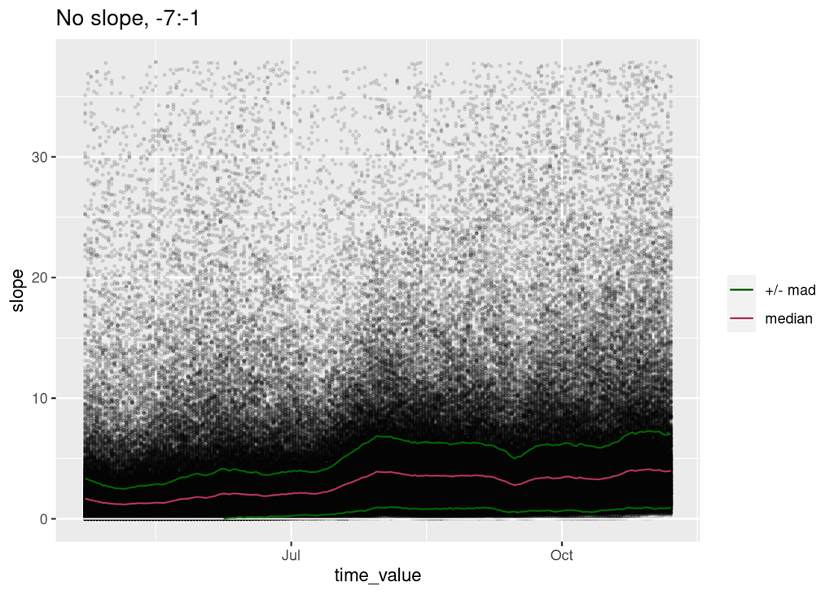

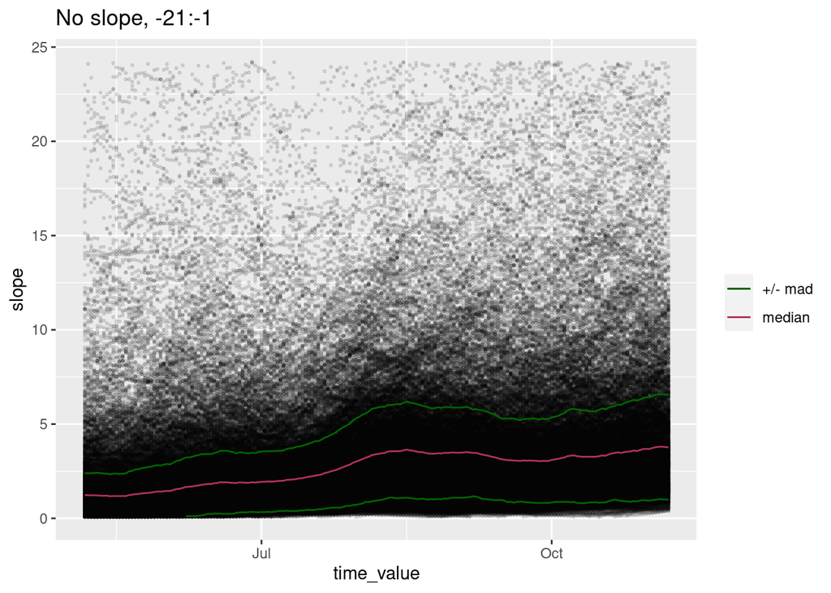

```r
QUANTS = c(0.01, 0.99)

titles = c('Longer time window (-42:-8)', 'No slope, -7:-1', 'No slope, -21:-1')
slope_dfs = list(lt_slopes, ns_slopes, ns_wider_slopes)

for (idx in 1:length(slope_dfs)) {
  cur_df = slope_dfs[[idx]]
  slope_limits <- quantile(cur_df$slope, QUANTS, na.rm=TRUE)
  plt = ggplot(
    cur_df,
    aes(x=time_value,
        y=slope),
  ) + geom_point (
    alpha=0.1,
    size=0.5,
  ) + geom_hline (
    yintercept=0,
    colour='white',
  ) + stat_summary (
      aes(y=slope,
          group=1,
          colour='median'),
      fun=median,
      geom="line",
      group=1,
  ) + stat_summary (
      aes(y=slope,
          group=1,
          colour='+/- mad'),
      fun=function(x) { median(x) + mad(x) },
      geom="line",
      group=1,
  ) + stat_summary (
      aes(y=slope,
          group=1,
          colour='+/- mad'),
      fun=function(x) { median(x) - mad(x) },
      geom="line",
      group=1,
  ) + scale_colour_manual(
      values=c("median"="maroon",
               "+/- mad"="darkgreen")
  ) + labs(
    colour=''
  ) + ggtitle(
    titles[idx]
  ) + ylim (
    slope_limits[[1]], slope_limits[[2]]
  )
  print(plt)
}
```